# FactorViz: A Visualization app for methylome decomposition experiments

Shashwat Sahay, Pavlo Lutsik, Michael Scherer

2019-12-12

# Introduction

```r
install.packages("devtools")
devtools::install_github("CompEpigen/FactorViz")
```

# Using FactorViz

## Default start-up

You can start *FactorViz* by using `startFactorViz()` command.

## Parameterized start-up

You can also initialise *FactorViz* by providing paths to the files or the DecompPipeline output to the `startFactorViz()` command. It accepts the following parameters.

- `decomp_output`: takes in the directory path to DecompPipeline output
- `medecom_set`: takes in the path to medecom set file
- `ann_C`: takes in the path to CpG Annotation file
- `ann_S`: takes in the path to Sample Annotation file
- `ref_meth`: takes in the path to Reference Methylome file

> Note: If decomp_output is provided all other parameters are force set to NULL

## Loading Data-sets

### Using DecompPipeline Output

If paramaters are not provided you can load the file by providing the path to DecompPipeline output directory (Fig 1a) in the user interface or by selecting the directory with the built-in file manager (Fig 1b, Fig 2)

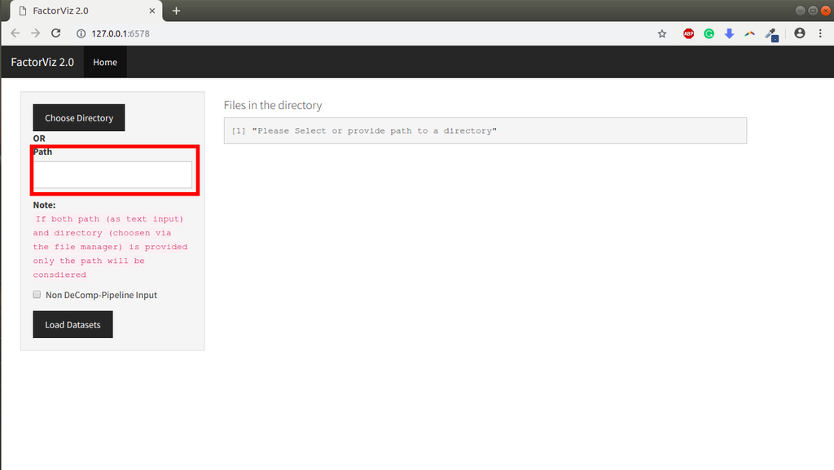

Fig 1a

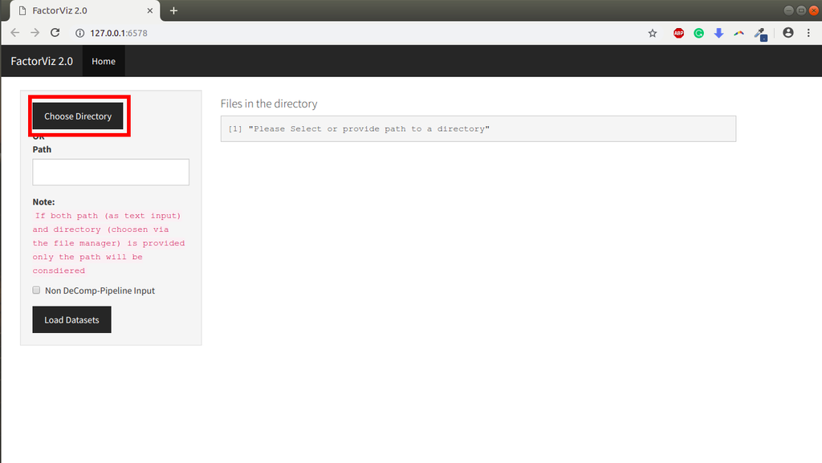

Fig 1b

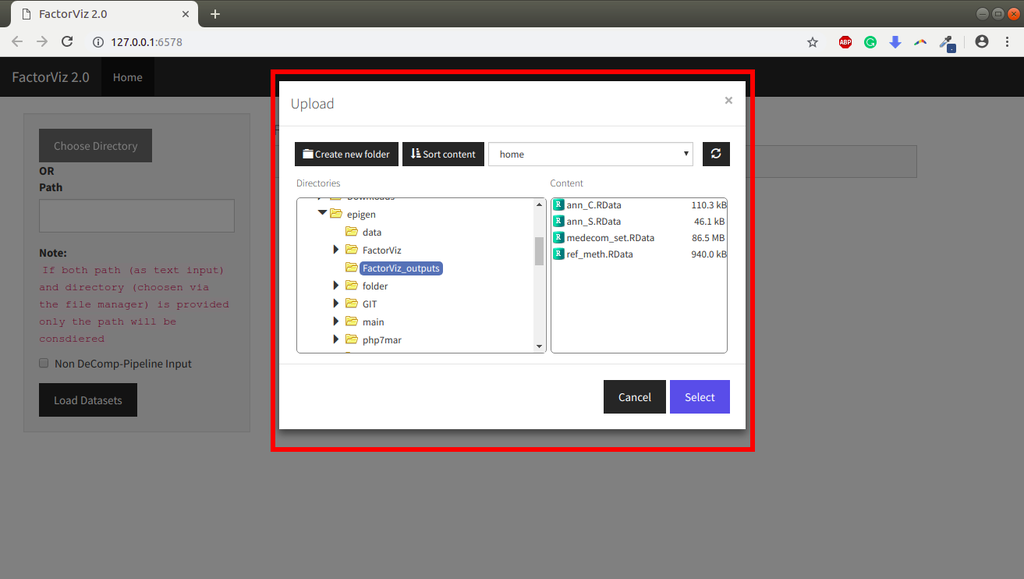

Fig 2

Once selected you can check the file names of that will be loaded into *FactorViz* in the UI (Fig 3).

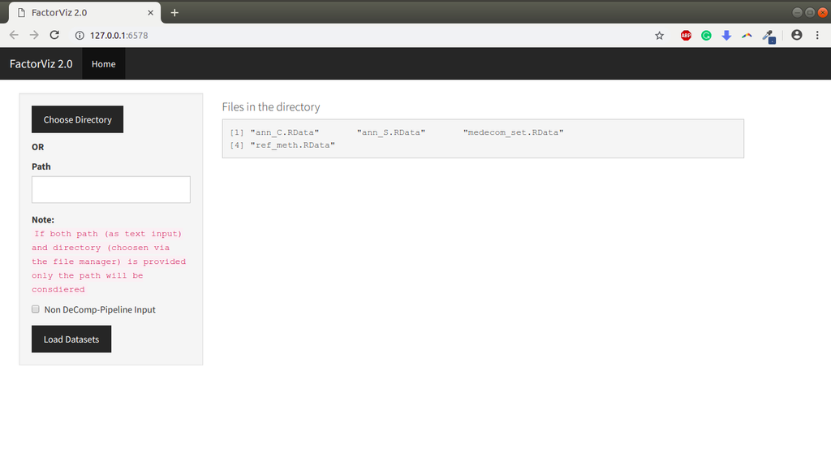

Fig 3

### Using Multiple Files

With *FactorViz* you can also load the dataset from multiple location by switching the Non DeCompPipeline checkbox (Fig 4)

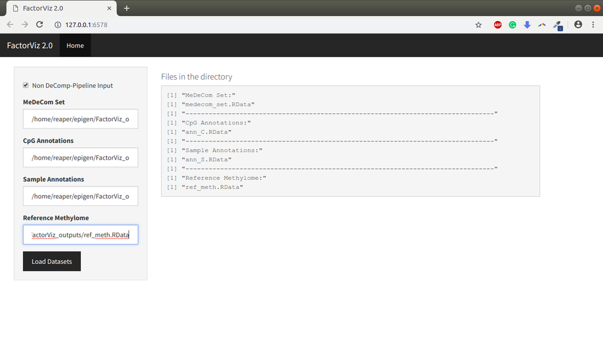

Fig 4

After the paths are set click on the `Load Dataset` button to load the dataset into *FactorViz* to carry out further analysis (Fig 5)

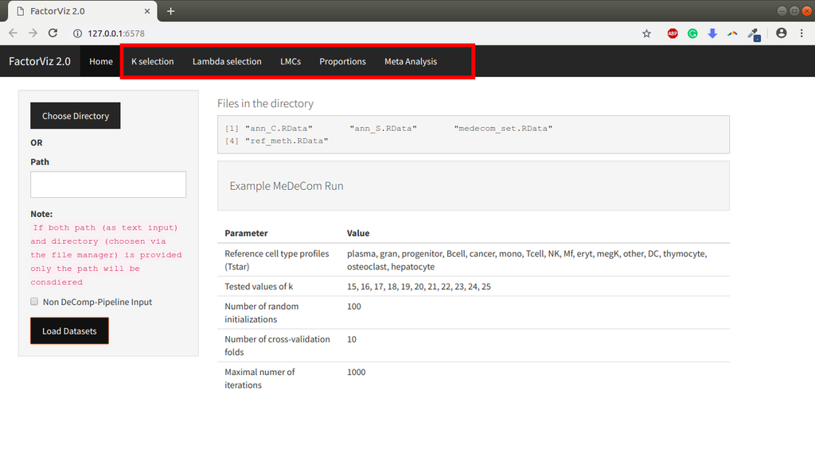

Fig 5

The further section of `K Selection, Lambda Selection, LMC, Proportions and Meta-Analysis` are explained in detail in MeDeCom documentation.